# Coupled Model Intercomparison Project Phase 6 - CMIP6

## Summary Description

The [Coupled Model Intercomparison Project](https://wcrp-cmip.org/) Phase 6 ([CMIP6](https://wcrp-cmip.org/cmip-phases/cmip6/)) is the latest iteration of the international effort of providing comparable, state of the art, global climate model simulations from multiple modeling centers around the world. CMIP is coordinated by the [World Climate Research Programme (WCRP)](https://www.wcrp-climate.org/) and is a cornerstone dataset for the [Intergovernmental Panel on Climat Changes Assessment Reports (IPCC AR6)](https://www.ipcc.ch/reports/). CMIP6 includes historical simulations, future scenarios (SSPs), and targeted experiments supporting studies on climate evolution, variability, extremes, and impacts. By defining common simulation protocols, CMIP enables the meaningful comparison of model results. More than 140 models from 52 institutions representing 26 countries contributed to CMIP6. A detailed description of CMIP6 is available in Eyring *et al.* (2016).

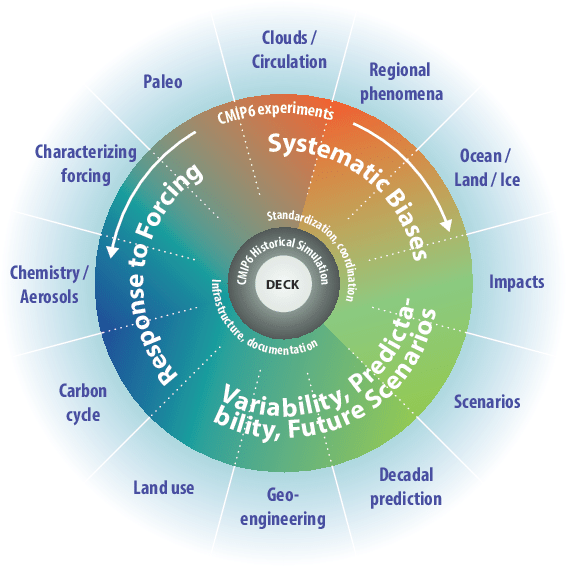

Schematic of the CMIP/CMIP6 experiment design  
(Source: Eyring *et al.* (2016))

## Dataset Characteristics

- **Current version:** CMIP6 (2019–present)
- **Available variables:** standard variables like temperature & precipitation, often many more; availability will vary by model and simulation (see variables section below)
- **Temporal coverage:** 1850–2100+
- **Temporal resolution:** model dependent, from hourly to monthly, all models provide daily.
- **Spatial coverage:** Global (land + ocean)
- **Spatial resolution:** ~1° to ~2° depending on model
- **Data type:** raw model output from climate simulations
- **Data format:** netCDF
- **Web references:**  
  [CMIP Phase 6 on WCRP web page](https://wcrp-cmip.org/cmip-phases/cmip6/)  
  [CMIP Phase 6 on PCMDI web page](https://pcmdi.llnl.gov/CMIP6/) (includes a map of the locations of modeling centers)
- **Reference:**  
  Eyring *et al.* (2016)
- **Contact:** For general CMIP6 inquiries, feedback, or information, contact the CMIP International Project Office (IPO)  
  For specific data queries or issues with Canadian data, contact the [Climate Services Support Desk](https://climate-change.canada.ca/support-desk)

## When to use CMIP6

- When you need **long-term climate change projections of future climate**
- When you want to assess **how different emissions pathways (SSPs)** impact future climate conditions
- When you want to explore **uncertainty across climate models** using **multi-model ensembles**
- When you are comfortable working with **coarse spatial resolution (~100–250 km)** and understand its limitations for local applications
- When you need **standardized experiments and protocols** across many climate models
- When you want to study **large-scale climate processes** (e.g., circulation, teleconnections, feedbacks)
- When you need **global, physically consistent simulations** of the Earth system

## Strengths and Limitations

### Key Strengths of CMIP6

| Strength | Description |
| --- | --- |
| **Reference Dataset** | CMIP is THE reference for simulations of Earth’s climate. |
| **Scenario Diversity** | Explores possible future climate under multiple Shared Socioeconomic Pathways (SSPs) and targeted experiments. |
| **Multi-Model Ensemble** | The variety of models, emission scenarios and member simulations allows to explore the uncertainty associated with climate projections through ensemble approaches. |
| **Global Coverage** | Provides climate projections for the entire globe, both land and ocean. |
| **Alignment with IPCC** | CMIP experiments align with the Intergovernmental Panel’s on Climate Change (IPCC) Assessment Reports. |

### Key Limitations of CMIP6

| Limitation | Description |
| --- | --- |
| **Coarse Resolution** | Grid spacing (~100 km) is often too coarse for local and regional climate change assessment. |
| **Biases in Climate Models** | Models are imperfect and have biases and limitations in their process representations. |
| **Raw data insufficiency** | Often requires downscaling and bias-correction for applied studies. |
| **Data Size and Complexity** | Multi-model, multi-variable datasets require substantial computer resources for production and storage. |

## Expert Guidance

**None(click to expand)**

Since its launch in 1995, the Coupled Model Intercomparison Project (CMIP) has coordinated international effort to improve understanding of past, present, and future climate. Each subsequent phase of the project provided ensembles of global climate model (GCM) simulations produced by research centers worldwide. These models have evolved through CMIP generations improving their representation of the physics, chemistry, and dynamics of the Earth system and are run under standardized experiments to explore key questions about climate variability and change, over Earth’s land and oceans.

A key strength of CMIP is the global coordination and transparency, with CMIP6 being the latest most comprehensive and standardized collection of GCM experiments. Modeling centers follow shared protocols defined by the World Climate Research Programme (WCRP), ensuring that outputs are broadly comparable. All data are publicly available, well-documented, and widely used in research and assessments such as the IPCC Sixth Assessment Report.

CMIP is a compilation of multiple experiments, starting with the basic DECK experiments (Diagnostic, Evaluation and Characterization of *Klima*, where *klima* is greek for climate), and including various “MIPs” ([Model Intercomparison Projects](https://wcrp-cmip.org/mips/)), such as historical forcing experiments (historical), future scenarios (ScenarioMIP), and specific processes (e.g., C4MIP for the carbon cycle, HighResMIP for resolution effects). With many different land surface, ocean and atmospheric variables available for time periods spanning from 1850 to 2100 and beyond, the diversity of CMIP6 enables analyses from long-term global projections to process-level studies.

The strength of the ensemble is that it allows for a multi-model perspective that provides a measure of robustness: when different models converge on a signal (e.g., global warming trends or precipitation shifts), confidence increases. The ensemble helps quantify uncertainty from structural differences among models. The process-based based models are Earth System representations with many CMIP6 models including coupled carbon cycles, interactive aerosols, and dynamic vegetation, enabling integrated assessments of feedbacks between climate, biogeochemistry, and ecosystems.

Despite appearing as a large ensemble, CMIP6 is not exactly a “random sample.” Through the decade long history of the development of these highly complex models, many models share components or parameterizations, so their errors and biases may be correlated. Treating them as statistically independent may overstate the robustness of ensemble means. Nevertheless, CMIP GCM ensembles provide the most comprehensiver understanding of Earth’s atmosphere and climate.

GCMs require massive parallel computing resources and simulations may take several months to complete. Computing power is a key constraint to the spatial resolution at which GCMs are operated. With a resolution of around 100 km (model dependent) GCM capture inadequately local processes such as topography, coastal effects, or convection which reduces their regional skill. Downscaling approaches (statistical or dynamical) are often required for regional or impact studies (see ESPO-G6-R2 , CanDCS-M6 and CRCM5-CMIP6 .

In CMIP6, a subset of models has an unusually strong warming response to greenhouse gases at the global level, leading to higher temperature projections than those typically supported by observations (Hausfather *et al.* (2022)). This “hot-model problem” means that results can appear more extreme than expected unless a model selection or model weighting is applied. However, how this stronger than expected warming translates at the local level in terms of impacts is not always clear. How to address this is an active field of research.

While CMIP ensembles reflect diversity in model structures their sampling of uncertainty may still be inclomplete regarding possible parameter choices or internal variability. Single model initial-condition large ensembles (SMILEs) (Maher *et al.* (2021)) seek to fill that gap by providing multiple runs from a single model to estimate and study internal variability.

Overall, CMIP6 is a powerful resource for understanding climate change at global to regional scales. While for most applications downscaled and/or bias-adjusted versions of the CMIP6 simulations are preferable, the source for these derived versions may be of interest for specific studies, exploration of otherwise unavailable variables, regions or time periods.

As illustrated above, CMIP encompasses numerous [Model Intercomparison Projects (MIPs)](https://wcrp-cmip.org/mips/) that address specific issues such as the carbon cycle or geoengineering. The MIPs commonly used for impact and adaptation studies are the [Scenario Model Intercomparison Project (ScenarioMIP)](https://wcrp-cmip.org/mips/scenariomip/) which carries out earth system model simulations driven by alternative plausible futures of emissions and land use and CORDEX which focuses on RCM simulations.

According to Working Group III of the IPCC’s sixth assessement report, SSP5-8.5 (like RCP8.5) does not represent a typical business-as-usual scenario and is currently considered unlikely. It is useful only as a high-risk scenario, representative of the upper limit of “no climate policy” scenarios. SSP5-8.5 may be relevant in the context of unlikely hazards with catastrophic consequences, or as an analogue for a post-2100 climate.

CMIP7 simulations are scheduled to become available in 2026.

## Variables available in CMIP6

Any of the CMIP6 models may produce variables from the the [IPCC list of standard output from Coupled Ocean-Atmosphere GCMs](https://pcmdi.llnl.gov/mips/cmip3/variableList.html). It comprises far over 100 different variables, and many more may be produced by a model and according to the CF-Conventions (see the [Climate and Forecast (CF) Standard Name Table](https://cfconventions.org/Data/cf-standard-names/current/build/cf-standard-name-table.html)). Depending on the model and its realizations, the respective list of available variables will be determined by the modeling center’s available resources and research focus. Hence, from some models many atmospheric and surface variables will be available, however the common denominator for most CMIP6 model simulations will be the variables listed below.

*Click on variable groups to uncollapse*

**NoneTemperature**

Temperature variables are provided at hourly to daily intervals, depending on the model and realization.

- mean temperature (day, 6hr, 3hr, 1hr) [K]
- daily minimum temperature [K]
- daily maximum temperature [K]

**NonePrecipitation**

Precipitation is commonly provided as the sum of solid and liquid precipitation or as snowfall and variables are provided at hourly to daily intervals, depending on the model and realization.

- Precipitation flux (day, 6hr, 3hr, 1hr) [kg m<sup>-2</sup> s<sup>-1</sup>]
- Snowfall flux [kg m<sup>-2</sup> s<sup>-1</sup>]

**NoneOther Variables**

Other variables often provided by a large number of models include:

- Wind (estward, westward) [m s<sup>-1</sup>]
- Specific or relative humidity [%]
- Longwave and shortwave radiation (downwelling and upwelling) [W m<sup>-2</sup>]

Further variables related to evaporation, runoff, and cloud cover may be available depending on the model.

## Data Access

Raw CMIP6 data are distributed through the [Earth System Grid Federation (ESGF)](https://esgf.github.io/index.html) and can be downloaded from one of their [Federated Metagrid Nodes](https://esgf.github.io/nodes.html). In North America the closest download points are the [node operated by the Oak Ridge National Laboratory (ORNL)](https://esgf-node.ornl.gov/) and the [Lawrence Livermore National Laboratory (LLNL) node](https://esgf-node.llnl.gov/).

The CMIP6 ensemble’s raw data forms the basis for post-processed and bias-adjusted ensemble data such as ESPO-G6-R2 and CanDCS-M6.

## References

Eyring, V., Bony, S., Meehl, G. A., … Taylor, K. E. (2016). [Overview of the coupled model intercomparison project phase 6 (CMIP6) experimental design and organization](https://doi.org/10.5194/gmd-9-1937-2016). *Geoscientific Model Development*, **9**(5), 1937–1958.

Hausfather, Z., Marvel, K., Schmidt, G. A., Nielsen-Gammon, J. W., & Zelinka, M. (2022). [Climate simulations: Recognize the ’hot model’ problem](https://doi.org/10.1038/d41586-022-01192-2). *Nature*, **605**(7908), 26–29.

Maher, N., Milinski, S., & Ludwig, R. (2021). [Large ensemble climate model simulations: Introduction, overview, and future prospects for utilising multiple types of large ensemble](https://doi.org/10.5194/esd-12-401-2021). *Earth System Dynamics*, **12**(2), 401–418.

Tebaldi, C., Debeire, K., Eyring, V., … Ziehn, T. (2021). [Climate model projections from the scenario model intercomparison project (ScenarioMIP) of CMIP6](https://doi.org/10.5194/esd-12-253-2021). *Earth System Dynamics*, **12**(1), 253–293.